# Risk Factor Analysis

## Outcome Variable

**Outcome Variable:** ever_wasted

## Predictor Variables

**Intervention Variable:** hdlvry

**Adjustment Set:**

unadjusted

## Stratifying Variables

The analysis was stratified on these variable(s):

- agecat
- studyid
- country

## Data Summary

| agecat | studyid | country | hdlvry | ever_wasted | n_cell | n |
| --- | --- | --- | --- | --- | --- | --- |
| 0-24 months (no birth wast) | CMC-V-BCS-2002 | INDIA | 0 | 0 | 196 | 365 |
| 0-24 months (no birth wast) | CMC-V-BCS-2002 | INDIA | 0 | 1 | 161 | 365 |
| 0-24 months (no birth wast) | CMC-V-BCS-2002 | INDIA | 1 | 0 | 5 | 365 |
| 0-24 months (no birth wast) | CMC-V-BCS-2002 | INDIA | 1 | 1 | 3 | 365 |
| 0-24 months (no birth wast) | COHORTS | INDIA | 0 | 0 | 2513 | 4904 |
| 0-24 months (no birth wast) | COHORTS | INDIA | 0 | 1 | 517 | 4904 |
| 0-24 months (no birth wast) | COHORTS | INDIA | 1 | 0 | 1423 | 4904 |
| 0-24 months (no birth wast) | COHORTS | INDIA | 1 | 1 | 451 | 4904 |
| 0-24 months (no birth wast) | EE | PAKISTAN | 0 | 0 | 117 | 375 |
| 0-24 months (no birth wast) | EE | PAKISTAN | 0 | 1 | 135 | 375 |
| 0-24 months (no birth wast) | EE | PAKISTAN | 1 | 0 | 56 | 375 |
| 0-24 months (no birth wast) | EE | PAKISTAN | 1 | 1 | 67 | 375 |
| 0-24 months (no birth wast) | GMS-Nepal | NEPAL | 0 | 0 | 83 | 613 |
| 0-24 months (no birth wast) | GMS-Nepal | NEPAL | 0 | 1 | 65 | 613 |
| 0-24 months (no birth wast) | GMS-Nepal | NEPAL | 1 | 0 | 221 | 613 |
| 0-24 months (no birth wast) | GMS-Nepal | NEPAL | 1 | 1 | 244 | 613 |
| 0-24 months (no birth wast) | IRC | INDIA | 0 | 0 | 190 | 409 |
| 0-24 months (no birth wast) | IRC | INDIA | 0 | 1 | 211 | 409 |
| 0-24 months (no birth wast) | IRC | INDIA | 1 | 0 | 6 | 409 |
| 0-24 months (no birth wast) | IRC | INDIA | 1 | 1 | 2 | 409 |
| 0-24 months (no birth wast) | NIH-Crypto | BANGLADESH | 0 | 0 | 513 | 754 |
| 0-24 months (no birth wast) | NIH-Crypto | BANGLADESH | 0 | 1 | 74 | 754 |
| 0-24 months (no birth wast) | NIH-Crypto | BANGLADESH | 1 | 0 | 133 | 754 |
| 0-24 months (no birth wast) | NIH-Crypto | BANGLADESH | 1 | 1 | 34 | 754 |
| 0-24 months (no birth wast) | PROVIDE | BANGLADESH | 0 | 0 | 427 | 687 |
| 0-24 months (no birth wast) | PROVIDE | BANGLADESH | 0 | 1 | 86 | 687 |
| 0-24 months (no birth wast) | PROVIDE | BANGLADESH | 1 | 0 | 138 | 687 |
| 0-24 months (no birth wast) | PROVIDE | BANGLADESH | 1 | 1 | 36 | 687 |
| 0-24 months (no birth wast) | SAS-CompFeed | INDIA | 0 | 0 | 120 | 1224 |
| 0-24 months (no birth wast) | SAS-CompFeed | INDIA | 0 | 1 | 44 | 1224 |

[output cut: 90 more lines]

The following strata were considered:

- agecat: 0-24 months (no birth wast), studyid: CMC-V-BCS-2002, country: INDIA
- agecat: 0-24 months (no birth wast), studyid: COHORTS, country: INDIA
- agecat: 0-24 months (no birth wast), studyid: EE, country: PAKISTAN
- agecat: 0-24 months (no birth wast), studyid: GMS-Nepal, country: NEPAL
- agecat: 0-24 months (no birth wast), studyid: IRC, country: INDIA
- agecat: 0-24 months (no birth wast), studyid: NIH-Crypto, country: BANGLADESH
- agecat: 0-24 months (no birth wast), studyid: PROVIDE, country: BANGLADESH
- agecat: 0-24 months (no birth wast), studyid: SAS-CompFeed, country: INDIA
- agecat: 0-24 months (no birth wast), studyid: SAS-FoodSuppl, country: INDIA
- agecat: 0-24 months (no birth wast), studyid: TanzaniaChild2, country: TANZANIA, UNITED REPUBLIC OF
- agecat: 0-6 months (no birth wast), studyid: CMC-V-BCS-2002, country: INDIA
- agecat: 0-6 months (no birth wast), studyid: COHORTS, country: INDIA
- agecat: 0-6 months (no birth wast), studyid: EE, country: PAKISTAN
- agecat: 0-6 months (no birth wast), studyid: GMS-Nepal, country: NEPAL
- agecat: 0-6 months (no birth wast), studyid: IRC, country: INDIA
- agecat: 0-6 months (no birth wast), studyid: NIH-Crypto, country: BANGLADESH
- agecat: 0-6 months (no birth wast), studyid: PROVIDE, country: BANGLADESH
- agecat: 0-6 months (no birth wast), studyid: SAS-CompFeed, country: INDIA
- agecat: 0-6 months (no birth wast), studyid: SAS-FoodSuppl, country: INDIA
- agecat: 0-6 months (no birth wast), studyid: TanzaniaChild2, country: TANZANIA, UNITED REPUBLIC OF
- agecat: 6-24 months, studyid: CMC-V-BCS-2002, country: INDIA
- agecat: 6-24 months, studyid: COHORTS, country: INDIA
- agecat: 6-24 months, studyid: EE, country: PAKISTAN
- agecat: 6-24 months, studyid: GMS-Nepal, country: NEPAL
- agecat: 6-24 months, studyid: IRC, country: INDIA
- agecat: 6-24 months, studyid: NIH-Crypto, country: BANGLADESH
- agecat: 6-24 months, studyid: PROVIDE, country: BANGLADESH
- agecat: 6-24 months, studyid: SAS-CompFeed, country: INDIA
- agecat: 6-24 months, studyid: SAS-FoodSuppl, country: INDIA
- agecat: 6-24 months, studyid: TanzaniaChild2, country: TANZANIA, UNITED REPUBLIC OF

### Dropped Strata

Some strata were dropped due to rare outcomes:

- agecat: 0-24 months (no birth wast), studyid: CMC-V-BCS-2002, country: INDIA
- agecat: 0-24 months (no birth wast), studyid: IRC, country: INDIA
- agecat: 0-6 months (no birth wast), studyid: CMC-V-BCS-2002, country: INDIA
- agecat: 0-6 months (no birth wast), studyid: IRC, country: INDIA
- agecat: 0-6 months (no birth wast), studyid: SAS-FoodSuppl, country: INDIA
- agecat: 0-6 months (no birth wast), studyid: TanzaniaChild2, country: TANZANIA, UNITED REPUBLIC OF
- agecat: 6-24 months, studyid: CMC-V-BCS-2002, country: INDIA
- agecat: 6-24 months, studyid: IRC, country: INDIA
- agecat: 6-24 months, studyid: TanzaniaChild2, country: TANZANIA, UNITED REPUBLIC OF

## Methods Detail

We’re interested in the causal parameters $E[Y_a]$ for all values of $a \in \mathcal{A}$. These parameters represent the mean outcome if, possibly contrary to fact, we intervened to set all units to have $A=a$. Under the randomization and positivity assumptions, these are identified by the statistical parameters $\psi_a=E_W[E_{Y|A,W}(Y|A=a,W)]$. In addition, we’re interested in the mean of $Y$, $E[Y]$ under no intervention (the observed mean). We will estimate these parameters by using SuperLearner to fit the relevant likelihood factors – $E_{Y|A,W}(Y|A=a,W)$ and $p(A=a|W)$, and then updating our likelihood fit using a joint TMLE.

For unadjusted analyses ($W=\{\}$), initial likelihoods were estimated using Lrnr_glm to estimate the simple $E(Y|A)$ and Lrnr_mean to estimate $p(A)$. For adjusted analyses, a small library containing Lrnr_glmnet, Lrnr_xgboost, and Lrnr_mean was used.

Having estimated these parameters, we will then use the delta method to estimate relative risks and attributable risks relative to a prespecified baseline level of $A$.

# Results Detail

## Results Plots

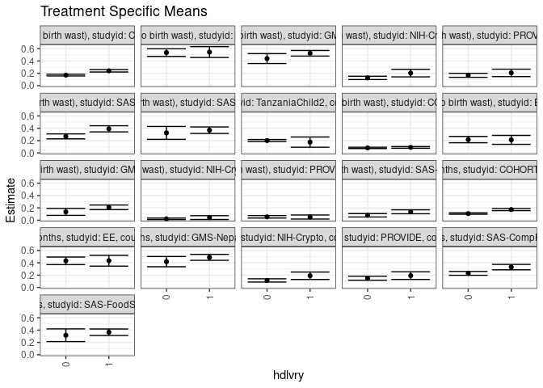

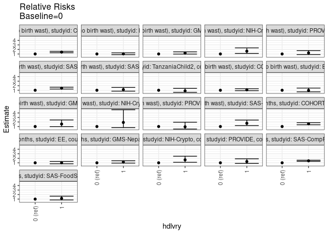

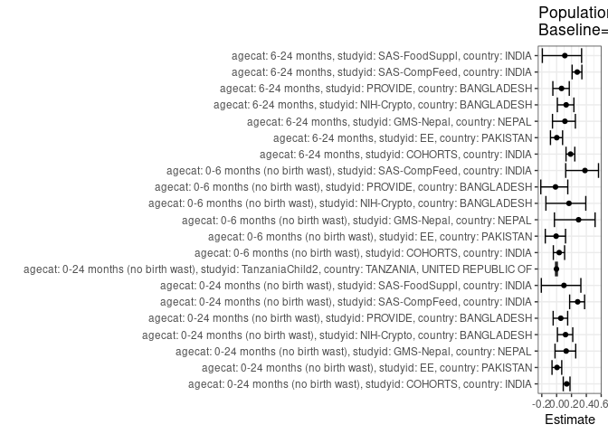

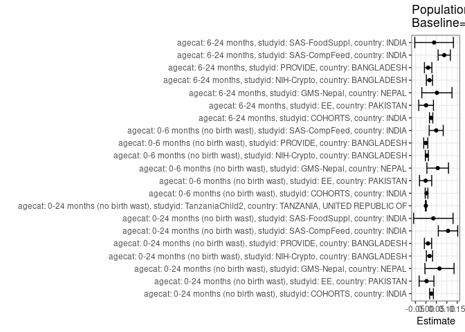

## Results Table

### Parameter: TSM

| agecat | studyid | country | intervention_level | baseline_level | estimate | ci_lower | ci_upper |
| --- | --- | --- | --- | --- | --- | --- | --- |
| 0-24 months (no birth wast) | COHORTS | INDIA | 0 | NA | 0.1706271 | 0.1572312 | 0.1840229 |
| 0-24 months (no birth wast) | COHORTS | INDIA | 1 | NA | 0.2406617 | 0.2213051 | 0.2600183 |
| 0-24 months (no birth wast) | EE | PAKISTAN | 0 | NA | 0.5357143 | 0.4740566 | 0.5973719 |
| 0-24 months (no birth wast) | EE | PAKISTAN | 1 | NA | 0.5447154 | 0.4565899 | 0.6328410 |
| 0-24 months (no birth wast) | GMS-Nepal | NEPAL | 0 | NA | 0.4391892 | 0.3591679 | 0.5192105 |
| 0-24 months (no birth wast) | GMS-Nepal | NEPAL | 1 | NA | 0.5247312 | 0.4793042 | 0.5701582 |
| 0-24 months (no birth wast) | NIH-Crypto | BANGLADESH | 0 | NA | 0.1260647 | 0.0991956 | 0.1529339 |
| 0-24 months (no birth wast) | NIH-Crypto | BANGLADESH | 1 | NA | 0.2035928 | 0.1424808 | 0.2647049 |
| 0-24 months (no birth wast) | PROVIDE | BANGLADESH | 0 | NA | 0.1676413 | 0.1352930 | 0.1999896 |
| 0-24 months (no birth wast) | PROVIDE | BANGLADESH | 1 | NA | 0.2068966 | 0.1466640 | 0.2671291 |
| 0-24 months (no birth wast) | SAS-CompFeed | INDIA | 0 | NA | 0.2682927 | 0.2277241 | 0.3088613 |
| 0-24 months (no birth wast) | SAS-CompFeed | INDIA | 1 | NA | 0.3905660 | 0.3407368 | 0.4403953 |
| 0-24 months (no birth wast) | SAS-FoodSuppl | INDIA | 0 | NA | 0.3246753 | 0.2199549 | 0.4293957 |
| 0-24 months (no birth wast) | SAS-FoodSuppl | INDIA | 1 | NA | 0.3687500 | 0.3158218 | 0.4216782 |
| 0-24 months (no birth wast) | TanzaniaChild2 | TANZANIA, UNITED REPUBLIC OF | 0 | NA | 0.2007201 | 0.1839373 | 0.2175028 |
| 0-24 months (no birth wast) | TanzaniaChild2 | TANZANIA, UNITED REPUBLIC OF | 1 | NA | 0.1750000 | 0.0916918 | 0.2583082 |
| 0-6 months (no birth wast) | COHORTS | INDIA | 0 | NA | 0.0816982 | 0.0715571 | 0.0918392 |
| 0-6 months (no birth wast) | COHORTS | INDIA | 1 | NA | 0.0893790 | 0.0759067 | 0.1028512 |
| 0-6 months (no birth wast) | EE | PAKISTAN | 0 | NA | 0.2160000 | 0.1649206 | 0.2670794 |
| 0-6 months (no birth wast) | EE | PAKISTAN | 1 | NA | 0.2113821 | 0.1391308 | 0.2836335 |
| 0-6 months (no birth wast) | GMS-Nepal | NEPAL | 0 | NA | 0.1347518 | 0.0783438 | 0.1911598 |
| 0-6 months (no birth wast) | GMS-Nepal | NEPAL | 1 | NA | 0.2087912 | 0.1714138 | 0.2461686 |
| 0-6 months (no birth wast) | NIH-Crypto | BANGLADESH | 0 | NA | 0.0222603 | 0.0102871 | 0.0342334 |
| 0-6 months (no birth wast) | NIH-Crypto | BANGLADESH | 1 | NA | 0.0424242 | 0.0116498 | 0.0731987 |
| 0-6 months (no birth wast) | PROVIDE | BANGLADESH | 0 | NA | 0.0550098 | 0.0351881 | 0.0748315 |
| 0-6 months (no birth wast) | PROVIDE | BANGLADESH | 1 | NA | 0.0517241 | 0.0187931 | 0.0846552 |
| 0-6 months (no birth wast) | SAS-CompFeed | INDIA | 0 | NA | 0.0797546 | 0.0518847 | 0.1076245 |
| 0-6 months (no birth wast) | SAS-CompFeed | INDIA | 1 | NA | 0.1366699 | 0.1045087 | 0.1688310 |
| 6-24 months | COHORTS | INDIA | 0 | NA | 0.1077291 | 0.0964903 | 0.1189679 |
| 6-24 months | COHORTS | INDIA | 1 | NA | 0.1727173 | 0.1553396 | 0.1900950 |
| 6-24 months | EE | PAKISTAN | 0 | NA | 0.4320000 | 0.3705137 | 0.4934863 |
| 6-24 months | EE | PAKISTAN | 1 | NA | 0.4344262 | 0.3463507 | 0.5225018 |
| 6-24 months | GMS-Nepal | NEPAL | 0 | NA | 0.4191176 | 0.3361160 | 0.5021193 |
| 6-24 months | GMS-Nepal | NEPAL | 1 | NA | 0.4891041 | 0.4408498 | 0.5373584 |
| 6-24 months | NIH-Crypto | BANGLADESH | 0 | NA | 0.1146384 | 0.0883975 | 0.1408794 |
| 6-24 months | NIH-Crypto | BANGLADESH | 1 | NA | 0.1901840 | 0.1298959 | 0.2504722 |
| 6-24 months | PROVIDE | BANGLADESH | 0 | NA | 0.1503268 | 0.1176048 | 0.1830488 |
| 6-24 months | PROVIDE | BANGLADESH | 1 | NA | 0.1923077 | 0.1304120 | 0.2542034 |
| 6-24 months | SAS-CompFeed | INDIA | 0 | NA | 0.2287582 | 0.1975422 | 0.2599741 |
| 6-24 months | SAS-CompFeed | INDIA | 1 | NA | 0.3302564 | 0.2864912 | 0.3740217 |
| 6-24 months | SAS-FoodSuppl | INDIA | 0 | NA | 0.3164557 | 0.2137688 | 0.4191426 |
| 6-24 months | SAS-FoodSuppl | INDIA | 1 | NA | 0.3653251 | 0.3127472 | 0.4179030 |

### Parameter: E(Y)

| agecat | studyid | country | intervention_level | baseline_level | estimate | ci_lower | ci_upper |
| --- | --- | --- | --- | --- | --- | --- | --- |
| 0-24 months (no birth wast) | COHORTS | INDIA | NA | NA | 0.1973899 | 0.1862487 | 0.2085311 |
| 0-24 months (no birth wast) | EE | PAKISTAN | NA | NA | 0.5386667 | 0.4881448 | 0.5891886 |
| 0-24 months (no birth wast) | GMS-Nepal | NEPAL | NA | NA | 0.5040783 | 0.4644662 | 0.5436904 |
| 0-24 months (no birth wast) | NIH-Crypto | BANGLADESH | NA | NA | 0.1432361 | 0.1182149 | 0.1682572 |
| 0-24 months (no birth wast) | PROVIDE | BANGLADESH | NA | NA | 0.1775837 | 0.1489858 | 0.2061816 |
| 0-24 months (no birth wast) | SAS-CompFeed | INDIA | NA | NA | 0.3741830 | 0.3195305 | 0.4288355 |
| 0-24 months (no birth wast) | SAS-FoodSuppl | INDIA | NA | NA | 0.3602015 | 0.3129196 | 0.4074834 |
| 0-24 months (no birth wast) | TanzaniaChild2 | TANZANIA, UNITED REPUBLIC OF | NA | NA | 0.2002653 | 0.1837694 | 0.2167611 |
| 0-6 months (no birth wast) | COHORTS | INDIA | NA | NA | 0.0846222 | 0.0765129 | 0.0927314 |
| 0-6 months (no birth wast) | EE | PAKISTAN | NA | NA | 0.2144772 | 0.1727666 | 0.2561878 |
| 0-6 months (no birth wast) | GMS-Nepal | NEPAL | NA | NA | 0.1912752 | 0.1596728 | 0.2228775 |
| 0-6 months (no birth wast) | NIH-Crypto | BANGLADESH | NA | NA | 0.0267023 | 0.0151493 | 0.0382553 |
| 0-6 months (no birth wast) | PROVIDE | BANGLADESH | NA | NA | 0.0541728 | 0.0371844 | 0.0711612 |
| 0-6 months (no birth wast) | SAS-CompFeed | INDIA | NA | NA | 0.1289517 | 0.0982960 | 0.1596075 |
| 6-24 months | COHORTS | INDIA | NA | NA | 0.1326445 | 0.1229894 | 0.1422995 |
| 6-24 months | EE | PAKISTAN | NA | NA | 0.4327957 | 0.3823792 | 0.4832122 |
| 6-24 months | GMS-Nepal | NEPAL | NA | NA | 0.4717668 | 0.4299709 | 0.5135628 |
| 6-24 months | NIH-Crypto | BANGLADESH | NA | NA | 0.1315068 | 0.1069744 | 0.1560393 |
| 6-24 months | PROVIDE | BANGLADESH | NA | NA | 0.1609756 | 0.1319065 | 0.1900447 |
| 6-24 months | SAS-CompFeed | INDIA | NA | NA | 0.3164894 | 0.2686679 | 0.3643108 |
| 6-24 months | SAS-FoodSuppl | INDIA | NA | NA | 0.3557214 | 0.3088651 | 0.4025777 |

### Parameter: RR

| agecat | studyid | country | intervention_level | baseline_level | estimate | ci_lower | ci_upper |
| --- | --- | --- | --- | --- | --- | --- | --- |
| 0-24 months (no birth wast) | COHORTS | INDIA | 0 | 0 | 1.0000000 | 1.0000000 | 1.000000 |
| 0-24 months (no birth wast) | COHORTS | INDIA | 1 | 0 | 1.4104544 | 1.2605095 | 1.578236 |
| 0-24 months (no birth wast) | EE | PAKISTAN | 0 | 0 | 1.0000000 | 1.0000000 | 1.000000 |
| 0-24 months (no birth wast) | EE | PAKISTAN | 1 | 0 | 1.0168022 | 0.8336989 | 1.240120 |
| 0-24 months (no birth wast) | GMS-Nepal | NEPAL | 0 | 0 | 1.0000000 | 1.0000000 | 1.000000 |
| 0-24 months (no birth wast) | GMS-Nepal | NEPAL | 1 | 0 | 1.1947725 | 0.9765124 | 1.461816 |
| 0-24 months (no birth wast) | NIH-Crypto | BANGLADESH | 0 | 0 | 1.0000000 | 1.0000000 | 1.000000 |
| 0-24 months (no birth wast) | NIH-Crypto | BANGLADESH | 1 | 0 | 1.6149862 | 1.1176011 | 2.333731 |
| 0-24 months (no birth wast) | PROVIDE | BANGLADESH | 0 | 0 | 1.0000000 | 1.0000000 | 1.000000 |
| 0-24 months (no birth wast) | PROVIDE | BANGLADESH | 1 | 0 | 1.2341620 | 0.8703371 | 1.750076 |
| 0-24 months (no birth wast) | SAS-CompFeed | INDIA | 0 | 0 | 1.0000000 | 1.0000000 | 1.000000 |
| 0-24 months (no birth wast) | SAS-CompFeed | INDIA | 1 | 0 | 1.4557461 | 1.2646017 | 1.675782 |
| 0-24 months (no birth wast) | SAS-FoodSuppl | INDIA | 0 | 0 | 1.0000000 | 1.0000000 | 1.000000 |
| 0-24 months (no birth wast) | SAS-FoodSuppl | INDIA | 1 | 0 | 1.1357500 | 0.7979245 | 1.616604 |
| 0-24 months (no birth wast) | TanzaniaChild2 | TANZANIA, UNITED REPUBLIC OF | 0 | 0 | 1.0000000 | 1.0000000 | 1.000000 |
| 0-24 months (no birth wast) | TanzaniaChild2 | TANZANIA, UNITED REPUBLIC OF | 1 | 0 | 0.8718610 | 0.5376976 | 1.413697 |
| 0-6 months (no birth wast) | COHORTS | INDIA | 0 | 0 | 1.0000000 | 1.0000000 | 1.000000 |
| 0-6 months (no birth wast) | COHORTS | INDIA | 1 | 0 | 1.0940145 | 0.8999557 | 1.329918 |
| 0-6 months (no birth wast) | EE | PAKISTAN | 0 | 0 | 1.0000000 | 1.0000000 | 1.000000 |
| 0-6 months (no birth wast) | EE | PAKISTAN | 1 | 0 | 0.9786209 | 0.6458126 | 1.482936 |
| 0-6 months (no birth wast) | GMS-Nepal | NEPAL | 0 | 0 | 1.0000000 | 1.0000000 | 1.000000 |
| 0-6 months (no birth wast) | GMS-Nepal | NEPAL | 1 | 0 | 1.5494505 | 0.9827714 | 2.442884 |
| 0-6 months (no birth wast) | NIH-Crypto | BANGLADESH | 0 | 0 | 1.0000000 | 1.0000000 | 1.000000 |
| 0-6 months (no birth wast) | NIH-Crypto | BANGLADESH | 1 | 0 | 1.9058275 | 0.7724891 | 4.701916 |
| 0-6 months (no birth wast) | PROVIDE | BANGLADESH | 0 | 0 | 1.0000000 | 1.0000000 | 1.000000 |
| 0-6 months (no birth wast) | PROVIDE | BANGLADESH | 1 | 0 | 0.9402709 | 0.4524178 | 1.954188 |
| 0-6 months (no birth wast) | SAS-CompFeed | INDIA | 0 | 0 | 1.0000000 | 1.0000000 | 1.000000 |
| 0-6 months (no birth wast) | SAS-CompFeed | INDIA | 1 | 0 | 1.7136300 | 1.2126862 | 2.421507 |
| 6-24 months | COHORTS | INDIA | 0 | 0 | 1.0000000 | 1.0000000 | 1.000000 |
| 6-24 months | COHORTS | INDIA | 1 | 0 | 1.6032549 | 1.3869388 | 1.853309 |
| 6-24 months | EE | PAKISTAN | 0 | 0 | 1.0000000 | 1.0000000 | 1.000000 |
| 6-24 months | EE | PAKISTAN | 1 | 0 | 1.0056163 | 0.7849688 | 1.288286 |
| 6-24 months | GMS-Nepal | NEPAL | 0 | 0 | 1.0000000 | 1.0000000 | 1.000000 |
| 6-24 months | GMS-Nepal | NEPAL | 1 | 0 | 1.1669853 | 0.9353548 | 1.455977 |
| 6-24 months | NIH-Crypto | BANGLADESH | 0 | 0 | 1.0000000 | 1.0000000 | 1.000000 |
| 6-24 months | NIH-Crypto | BANGLADESH | 1 | 0 | 1.6589901 | 1.1221029 | 2.452759 |
| 6-24 months | PROVIDE | BANGLADESH | 0 | 0 | 1.0000000 | 1.0000000 | 1.000000 |
| 6-24 months | PROVIDE | BANGLADESH | 1 | 0 | 1.2792642 | 0.8673888 | 1.886717 |
| 6-24 months | SAS-CompFeed | INDIA | 0 | 0 | 1.0000000 | 1.0000000 | 1.000000 |
| 6-24 months | SAS-CompFeed | INDIA | 1 | 0 | 1.4436923 | 1.3201971 | 1.578740 |
| 6-24 months | SAS-FoodSuppl | INDIA | 0 | 0 | 1.0000000 | 1.0000000 | 1.000000 |
| 6-24 months | SAS-FoodSuppl | INDIA | 1 | 0 | 1.1544272 | 0.8094738 | 1.646381 |

### Parameter: PAR

| agecat | studyid | country | intervention_level | baseline_level | estimate | ci_lower | ci_upper |
| --- | --- | --- | --- | --- | --- | --- | --- |
| 0-24 months (no birth wast) | COHORTS | INDIA | 0 | NA | 0.0267628 | 0.0177171 | 0.0358086 |
| 0-24 months (no birth wast) | EE | PAKISTAN | 0 | NA | 0.0029524 | -0.0323278 | 0.0382326 |
| 0-24 months (no birth wast) | GMS-Nepal | NEPAL | 0 | NA | 0.0648891 | -0.0049715 | 0.1347498 |
| 0-24 months (no birth wast) | NIH-Crypto | BANGLADESH | 0 | NA | 0.0171713 | 0.0022077 | 0.0321350 |
| 0-24 months (no birth wast) | PROVIDE | BANGLADESH | 0 | NA | 0.0099424 | -0.0074210 | 0.0273057 |
| 0-24 months (no birth wast) | SAS-CompFeed | INDIA | 0 | NA | 0.1058903 | 0.0593858 | 0.1523948 |
| 0-24 months (no birth wast) | SAS-FoodSuppl | INDIA | 0 | NA | 0.0355262 | -0.0590676 | 0.1301200 |
| 0-24 months (no birth wast) | TanzaniaChild2 | TANZANIA, UNITED REPUBLIC OF | 0 | NA | -0.0004548 | -0.0025840 | 0.0016743 |
| 0-6 months (no birth wast) | COHORTS | INDIA | 0 | NA | 0.0029240 | -0.0034963 | 0.0093443 |
| 0-6 months (no birth wast) | EE | PAKISTAN | 0 | NA | -0.0015228 | -0.0307019 | 0.0276563 |
| 0-6 months (no birth wast) | GMS-Nepal | NEPAL | 0 | NA | 0.0565234 | 0.0048024 | 0.1082444 |
| 0-6 months (no birth wast) | NIH-Crypto | BANGLADESH | 0 | NA | 0.0044420 | -0.0028570 | 0.0117410 |
| 0-6 months (no birth wast) | PROVIDE | BANGLADESH | 0 | NA | -0.0008371 | -0.0106296 | 0.0089555 |
| 0-6 months (no birth wast) | SAS-CompFeed | INDIA | 0 | NA | 0.0491971 | 0.0155107 | 0.0828836 |
| 6-24 months | COHORTS | INDIA | 0 | NA | 0.0249153 | 0.0169303 | 0.0329003 |
| 6-24 months | EE | PAKISTAN | 0 | NA | 0.0007957 | -0.0344318 | 0.0360232 |
| 6-24 months | GMS-Nepal | NEPAL | 0 | NA | 0.0526492 | -0.0196205 | 0.1249189 |
| 6-24 months | NIH-Crypto | BANGLADESH | 0 | NA | 0.0168684 | 0.0020103 | 0.0317265 |
| 6-24 months | PROVIDE | BANGLADESH | 0 | NA | 0.0106488 | -0.0071692 | 0.0284669 |
| 6-24 months | SAS-CompFeed | INDIA | 0 | NA | 0.0877312 | 0.0584409 | 0.1170215 |
| 6-24 months | SAS-FoodSuppl | INDIA | 0 | NA | 0.0392657 | -0.0534474 | 0.1319788 |

### Parameter: PAF

| agecat | studyid | country | intervention_level | baseline_level | estimate | ci_lower | ci_upper |
| --- | --- | --- | --- | --- | --- | --- | --- |
| 0-24 months (no birth wast) | COHORTS | INDIA | 0 | NA | 0.1355836 | 0.0889090 | 0.1798670 |
| 0-24 months (no birth wast) | EE | PAKISTAN | 0 | NA | 0.0054809 | -0.0622221 | 0.0688687 |
| 0-24 months (no birth wast) | GMS-Nepal | NEPAL | 0 | NA | 0.1287282 | -0.0218272 | 0.2571009 |
| 0-24 months (no birth wast) | NIH-Crypto | BANGLADESH | 0 | NA | 0.1198814 | 0.0106385 | 0.2170619 |
| 0-24 months (no birth wast) | PROVIDE | BANGLADESH | 0 | NA | 0.0559870 | -0.0467580 | 0.1486470 |
| 0-24 months (no birth wast) | SAS-CompFeed | INDIA | 0 | NA | 0.2829907 | 0.1752629 | 0.3766471 |
| 0-24 months (no birth wast) | SAS-FoodSuppl | INDIA | 0 | NA | 0.0986286 | -0.2062498 | 0.3264494 |
| 0-24 months (no birth wast) | TanzaniaChild2 | TANZANIA, UNITED REPUBLIC OF | 0 | NA | -0.0022711 | -0.0129474 | 0.0082927 |
| 0-6 months (no birth wast) | COHORTS | INDIA | 0 | NA | 0.0345536 | -0.0443129 | 0.1074641 |
| 0-6 months (no birth wast) | EE | PAKISTAN | 0 | NA | -0.0071000 | -0.1527613 | 0.1201558 |
| 0-6 months (no birth wast) | GMS-Nepal | NEPAL | 0 | NA | 0.2955083 | -0.0297857 | 0.5180467 |
| 0-6 months (no birth wast) | NIH-Crypto | BANGLADESH | 0 | NA | 0.1663527 | -0.1444437 | 0.3927462 |
| 0-6 months (no birth wast) | PROVIDE | BANGLADESH | 0 | NA | -0.0154516 | -0.2132370 | 0.1500903 |
| 0-6 months (no birth wast) | SAS-CompFeed | INDIA | 0 | NA | 0.3815159 | 0.1228762 | 0.5638899 |
| 6-24 months | COHORTS | INDIA | 0 | NA | 0.1878353 | 0.1266177 | 0.2447621 |
| 6-24 months | EE | PAKISTAN | 0 | NA | 0.0018385 | -0.0829677 | 0.0800036 |
| 6-24 months | GMS-Nepal | NEPAL | 0 | NA | 0.1116000 | -0.0558122 | 0.2524670 |
| 6-24 months | NIH-Crypto | BANGLADESH | 0 | NA | 0.1282701 | 0.0097770 | 0.2325840 |
| 6-24 months | PROVIDE | BANGLADESH | 0 | NA | 0.0661517 | -0.0508966 | 0.1701632 |
| 6-24 months | SAS-CompFeed | INDIA | 0 | NA | 0.2772011 | 0.2084514 | 0.3399795 |
| 6-24 months | SAS-FoodSuppl | INDIA | 0 | NA | 0.1103833 | -0.1924390 | 0.3363032 |